# R で学ぶゲーム理論

DS-SL

2023-06-04

> 表題の本の内容を学ぶためのファイル

# 1 Setup

```r
install.packages("remotes")
remotes::install_github("yukiyanai/rgamer")
```

```r
library(tidyverse)
library(rgamer)
```

必要なときに、実行

```r
library(showtext)
showtext_auto()
```

```r
theme_set(theme_gray(base_family = "HiraginoSans-W3"))
```

# 2 R で体感するゲーム理論

```r
game1 <- normal_form(
  players = c("矢内", "上條"),
  s1 = c("表", "裏"),
  s2 = c("表", "裏"),
  payoffs1 = c(1,0,0,1),
  payoffs2 = c(0,1,1,0)
)
```

```r
s1_sol1 <- solve_nfg(game1)
```

```
Pure strategy NE does not exist.
```

|  | strategy | 上條 表 | 上條 裏 |
| --- | --- | --- | --- |
| 矢内 | 表 | 1^, 0 | 0, 1^ |
|  | 裏 | 0, 1^ | 1^, 0 |

```r
g1_sol2 <- solve_nfg(game1, mixed = TRUE)
```

```
Pure strategy NE does not exist.

Mixed-strategy NE: [(1/2, 1/2), (1/2, 1/2)]

The obtained mixed-strategy NE might be only a part of the solutions.
Please examine br_plot (best response plot) carefully.
```

|  | strategy | 上條 表 | 上條 裏 |
| --- | --- | --- | --- |
| 矢内 | 表 | 1^, 0 | 0, 1^ |
|  | 裏 | 0, 1^ | 1^, 0 |

```r
g1_sol2$msNE
```

```
$s1
[1] 0.5 0.5

$s2
[1] 0.5 0.5
```

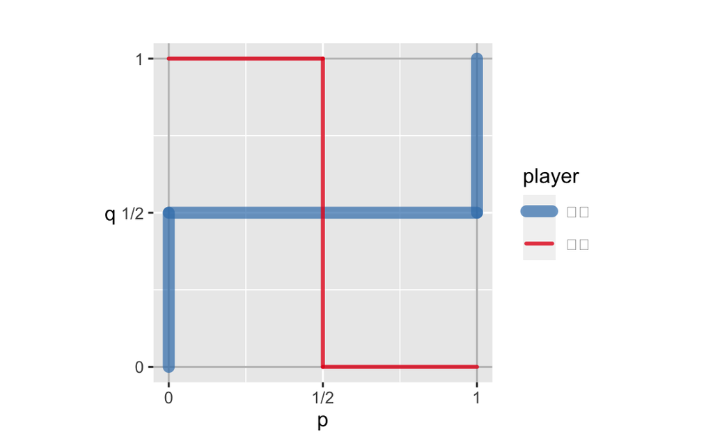

```r
g1_sol2$br_plot
```

```r
g1_sim <- sim_game(game1,
                   n_samples = 100,
                   n_periods = 50)
```

|  | t | l | b | r |
| --- | --- | --- | --- | --- |
| 1: | 1 | 1 | 1 | 1 |
| 2: | 1 | 2 | 1 | 2 |

```r
a <- 25
sqrt(a)
```

```
[1] 5
```

# 3 ゲームの定義と合理的なプレーヤー

```r
game2_1 <- normal_form(
  players = c("矢内", "上條"),
  s1 = c("表", "裏"),
  s2 = c("表", "裏"),
  payoffs1 = c(1,0,0,1),
  payoffs2 = c(0,1,1,0)
)
```

```r
g2_1_sol <- solve_nfg(game2_1)
```

```
Pure strategy NE does not exist.
```

|  | strategy | 上條 表 | 上條 裏 |
| --- | --- | --- | --- |
| 矢内 | 表 | 1^, 0 | 0, 1^ |
|  | 裏 | 0, 1^ | 1^, 0 |

```r
game2_2 <- normal_form(
  players = c("矢内", "上條"),
  s1 = c("グー", "チョキ", "パー"),
  s2 = c("グー", "チョキ", "パー"),
  payoffs1 = c(1,0,2,2,1,0,0,2,1),
  payoffs2 = c(0,2,0,0,1,2,2,0,1)
)
```

```r
g2_2_sol <- solve_nfg(game2_2)
```

```
Pure strategy NE does not exist.
```

|  | strategy | 上條 グー | 上條 チョキ | 上條 パー |
| --- | --- | --- | --- | --- |
| 矢内 | グー | 1, 0 | 2^, 0 | 0, 2^ |
|  | チョキ | 0, 2^ | 1, 1 | 2^, 0 |
|  | パー | 2^, 0 | 0, 2^ | 1, 1 |

# 4 支配戦略と支配される戦略の繰り返し消去

```r
game3_1 <- normal_form(
  players = c("上條", "矢内"),
  s1 = c("グー", "チョキ", "パー"),
  s2 = c("グー", "チョキ", "パー"),
  payoffs1 = c(0,0,2,2,0,0,0,2,2),
  payoffs2 = c(2,2,0,0,2,2,2,0,0)
)
```

```r
solve_nfg(game3_1, mark_br = FALSE)$table
```

```
Pure strategy NE does not exist.
```

|  | strategy | 矢内 グー | 矢内 チョキ | 矢内 パー |
| --- | --- | --- | --- | --- |
| 上條 | グー | 0, 2 | 2, 0 | 0, 2 |
|  | チョキ | 0, 2 | 0, 2 | 2, 0 |
|  | パー | 2, 0 | 0, 2 | 2, 0 |

|  | strategy | 矢内 グー | 矢内 チョキ | 矢内 パー |
| --- | --- | --- | --- | --- |
| 上條 | グー | 0, 2 | 2, 0 | 0, 2 |
|  | チョキ | 0, 2 | 0, 2 | 2, 0 |
|  | パー | 2, 0 | 0, 2 | 2, 0 |

オッズ

$$\frac{5/9}{4/9} = \frac{5}{4} =
1.25.$$

しかし、上條は、グーとパーだけ出せば良い。たとで、矢内が、グーと、チョキだけだしても結果は同じ。公平。

上條のチョキはパーに弱く支配されている。弱支配：weakly dominated.

```r
g3_1_dominated <- dom(game3_1)
```

```
上條's dominated strategy: NA
上條's weakly dominated strategy: チョキ
矢内's dominated strategy: NA
矢内's weakly dominated strategy: パー
```

1. 全部食べる 10
2. スイッチを押しに行く -1
3. 両方ともが食べる場合 大豚 8、子豚 2

```r
game3_2 <- normal_form(
  players = c("大豚", "子豚"),
  s1 = c("スイッチ", "待つ"),
  s2 = c("スイッチ", "待つ"),
  payoffs1 = c(7,10,4,0),
  payoffs2 = c(1,-1,5,0)
)

solve_nfg(game3_2, mark_br = FALSE)$table
```

```
Pure-strategy NE: [スイッチ, 待つ]
```

|  | strategy | 子豚 スイッチ | 子豚 待つ |
| --- | --- | --- | --- |
| 大豚 | スイッチ | 7, 1 | 4, 5 |
|  | 待つ | 10, -1 | 0, 0 |

|  | strategy | 子豚 スイッチ | 子豚 待つ |
| --- | --- | --- | --- |
| 大豚 | スイッチ | 7, 1 | 4, 5 |
|  | 待つ | 10, -1 | 0, 0 |

```r
game3_2a <- eliminate_strategy(
  game3_2,
  player = "子豚",
  eliminated = "スイッチ"
)

solve_nfg(game3_2a, mark_br = FALSE)$table
```

```
Pure-strategy NE: [スイッチ, 待つ]
```

|  | strategy | 子豚 待つ |
| --- | --- | --- |
| 大豚 | スイッチ | 4, 5 |
|  | 待つ | 0, 0 |

|  | strategy | 子豚 待つ |
| --- | --- | --- |
| 大豚 | スイッチ | 4, 5 |
|  | 待つ | 0, 0 |

```r
g3_2a_dominated <- dom(game3_2a)
```

```
大豚's dominated strategy: 待つ
大豚's weakly dominated strategy: 待つ
子豚's dominated strategy: NA
子豚's weakly dominated strategy: NA
```

```r
game3_2b <- eliminate_strategy(
  game3_2a,
  player = "大豚",
  eliminated = "待つ"
)

solve_nfg(game3_2b, mark_br = FALSE)$table
```

```
Pure-strategy NE: [スイッチ, 待つ]
```

|  | strategy | 子豚 待つ |
| --- | --- | --- |
| 大豚 | スイッチ | 4, 5 |

|  | strategy | 子豚 待つ |
| --- | --- | --- |
| 大豚 | スイッチ | 4, 5 |

```r
g3_2b_dominated <- dom(game3_2b)
```

```
大豚's dominated strategy: NA
大豚's weakly dominated strategy: NA
子豚's dominated strategy: NA
子豚's weakly dominated strategy: NA
```

```r
g3_1_dominant <- dom(game3_1, type = "dominant")
```

```
矢内's dominant strategy: NA
矢内's weakly dominant strategy: NA
上條's dominant strategy: NA
上條's weakly dominant strategy: NA
```

```r
g3_2_dominant <- dom(game3_2, type = "dominant")
```

```
大豚's dominant strategy: NA
大豚's weakly dominant strategy: NA
子豚's dominant strategy: 待つ
子豚's weakly dominant strategy: 待つ
```

## 4.1 練習問題

1. `game3_1` であいこは常に矢内が勝利するとするとどうなるか。関数 `dom()` を用いて分析せよ。

```r
game3_1x <- normal_form(
  players = c("上條", "矢内"),
  s1 = c("グー", "チョキ", "パー"),
  s2 = c("グー", "チョキ", "パー"),
  payoffs1 = c(0,0,2,2,0,0,0,2,0),
  payoffs2 = c(2,2,0,0,2,2,2,0,2)
)

solve_nfg(game3_1x, mark_br = FALSE)$table
```

```
Pure strategy NE does not exist.
```

|  | strategy | 矢内 グー | 矢内 チョキ | 矢内 パー |
| --- | --- | --- | --- | --- |
| 上條 | グー | 0, 2 | 2, 0 | 0, 2 |
|  | チョキ | 0, 2 | 0, 2 | 2, 0 |
|  | パー | 2, 0 | 0, 2 | 0, 2 |

|  | strategy | 矢内 グー | 矢内 チョキ | 矢内 パー |
| --- | --- | --- | --- | --- |
| 上條 | グー | 0, 2 | 2, 0 | 0, 2 |
|  | チョキ | 0, 2 | 0, 2 | 2, 0 |
|  | パー | 2, 0 | 0, 2 | 0, 2 |

```r
g3_1x_dominated <- dom(game3_1x)
```

```
上條's dominated strategy: NA
上條's weakly dominated strategy: NA
矢内's dominated strategy: NA
矢内's weakly dominated strategy: NA
```

```r
g3_1x_dominant <- dom(game3_1x, type = "dominant")
```

```
上條's dominant strategy: NA
上條's weakly dominant strategy: NA
矢内's dominant strategy: NA
矢内's weakly dominant strategy: NA
```

2. `game3_2` で、大豚がスイッチを押すには、-5 とする。このとき、大豚と、子豚は何を選択するか。

```r
game3_2x <- normal_form(
  players = c("大豚", "子豚"),
  s1 = c("スイッチ", "待つ"),
  s2 = c("スイッチ", "待つ"),
  payoffs1 = c(3,10,0,0),
  payoffs2 = c(1,-1,-1,0)
)

solve_nfg(game3_2x, mark_br = FALSE)$table
```

```
Pure-strategy NE: [待つ, 待つ]
```

|  | strategy | 子豚 スイッチ | 子豚 待つ |
| --- | --- | --- | --- |
| 大豚 | スイッチ | 3, 1 | 0, -1 |
|  | 待つ | 10, -1 | 0, 0 |

|  | strategy | 子豚 スイッチ | 子豚 待つ |
| --- | --- | --- | --- |
| 大豚 | スイッチ | 3, 1 | 0, -1 |
|  | 待つ | 10, -1 | 0, 0 |

```r
g3_2x_dominated <- dom(game3_2x)
```

```
大豚's dominated strategy: NA
大豚's weakly dominated strategy: スイッチ
子豚's dominated strategy: NA
子豚's weakly dominated strategy: NA
```

```r
g3_2x_dominant <- dom(game3_2x, type = "dominant")
```

```
大豚's dominant strategy: NA
大豚's weakly dominant strategy: 待つ
子豚's dominant strategy: NA
子豚's weakly dominant strategy: NA
```

# 5 ナッシュ均衡

## 5.1 支配関係と最適反応

囚人のジレンマ

```r
game4_1 <- normal_form(
  players = c("A", "B"),
  s1 = c("黙秘", "自白"),
  s2 = c("黙秘", "自白"),
  payoffs1 = c(-2, -1, -10, -5),
  payoffs2 = c(-2, -10, -1, -5)
)

g4_1_sol <- solve_nfg(game4_1, mark_br = TRUE)
```

```
Pure-strategy NE: [自白, 自白]
```

|  | strategy | B 黙秘 | B 自白 |
| --- | --- | --- | --- |
| A | 黙秘 | -2, -2 | -10, -1^ |
|  | 自白 | -1^, -10 | -5^, -5^ |

```r
g4_1_dominant <- dom(game4_1, type = "dominant")
```

```
A's dominant strategy: 自白
A's weakly dominant strategy: 自白
B's dominant strategy: 自白
B's weakly dominant strategy: 自白
```

合理的な豚の反応の表示

```r
g3_2_sol <- solve_nfg(game3_2, mark_br = TRUE)
```

```
Pure-strategy NE: [スイッチ, 待つ]
```

|  | strategy | 子豚 スイッチ | 子豚 待つ |
| --- | --- | --- | --- |
| 大豚 | スイッチ | 7, 1 | 4^, 5^ |
|  | 待つ | 10^, -1 | 0, 0^ |

```r
game4_2 <- normal_form(
  players = c("1", "2"),
  s1 = c("T", "M", "B"),
  s2 = c("L", "C", "R"),
  payoffs1 = c(1,0,0,0,1,0,0,0,1),
  payoffs2 = c(0,0,1,0,1,0,1,0,0)
)

g4_2_sol <- solve_nfg(game4_2, mark_br = TRUE)
```

```
Pure-strategy NE: [M, C]
```

|  | strategy | 2 L | 2 C | 2 R |
| --- | --- | --- | --- | --- |
| 1 | T | 1^, 0 | 0, 0 | 0, 1^ |
|  | M | 0, 0 | 1^, 1^ | 0, 0 |
|  | B | 0, 1^ | 0, 0 | 1^, 0 |

合理的な豚のシミュレーション

```r
g3_2_sim <- sim_game(game3_2,
                     n_samples = 100,
                     n_periods = 8)
```

|  | t | l | b | r |
| --- | --- | --- | --- | --- |
| 1: | 1 | 1 | 1 | 1 |
| 2: | 1 | 2 | 1 | 2 |

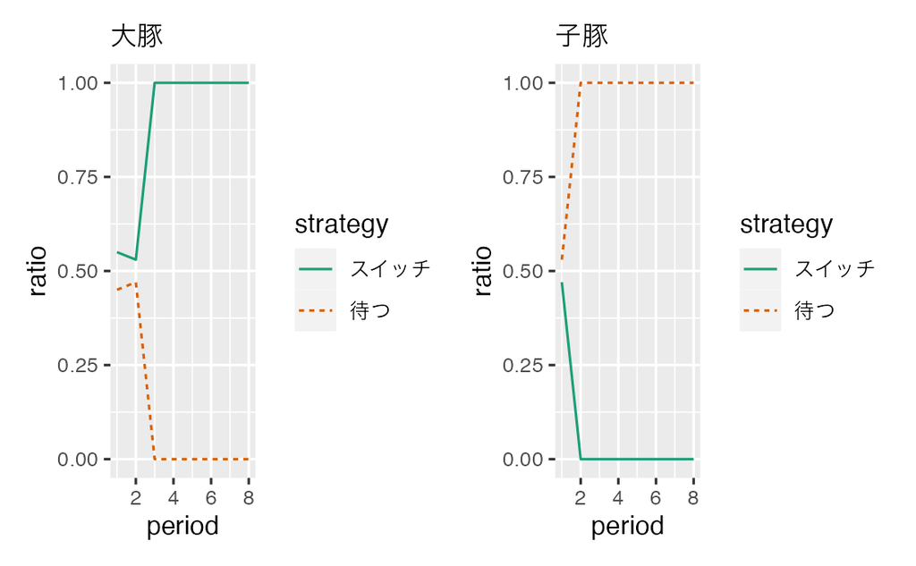

```r
g3_2_sim$plot_mean
```

## 5.2 練習問題

```
sim_game(
  game,
  n_samples,
  n_periods,
  type = "br",
  init1 = NULL,
  init2 = NULL,
  omega = 0,
  eta = 0.1,
  lambda = 1,
  cons1 = NULL,
  cons2 = NULL,
  plot_range_y = NULL
)
```

1. `game4_1` を関数、`sim_game()` でシミュレーションし、ナッシュ均衡に到達できるか確認。

```r
game4_1x <- normal_form(
  players = c("A", "B"),
  s1 = c("黙秘", "自白"),
  s2 = c("黙秘", "自白"),
  payoffs1 = c(-2, -1, -10, -5),
  payoffs2 = c(-2, -10, -1, -5)
)

g4_1x_sol <- solve_nfg(game4_1x, mark_br = TRUE)
```

```
Pure-strategy NE: [自白, 自白]
```

|  | strategy | B 黙秘 | B 自白 |
| --- | --- | --- | --- |
| A | 黙秘 | -2, -2 | -10, -1^ |
|  | 自白 | -1^, -10 | -5^, -5^ |

```r
g4_1x_dominant <- dom(game4_1x, type = "dominant")
```

```
A's dominant strategy: 自白
A's weakly dominant strategy: 自白
B's dominant strategy: 自白
B's weakly dominant strategy: 自白
```

```r
g4_1x_sim <- sim_game(game4_1x,
                     n_samples = 100,
                     n_periods = 8)
```

|  | t | l | b | r |
| --- | --- | --- | --- | --- |
| 1: | 1 | 1 | 1 | 1 |
| 2: | 1 | 2 | 1 | 2 |

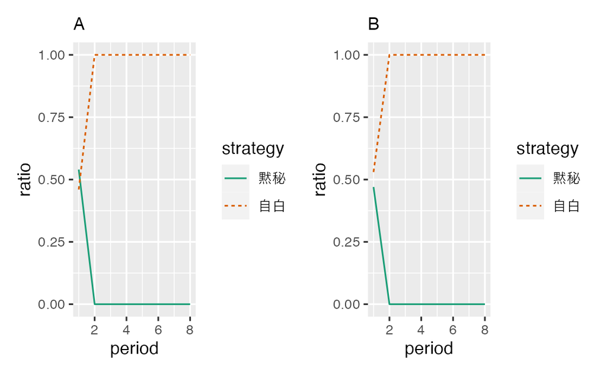

```r
g4_1x_sim$plot_mean
```

2. `game4_2` を関数、`sim_game()` でシミュレーションし、ナッシュ均衡に到達できるか確認。

```r
game4_2x <- normal_form(
  players = c("1", "2"),
  s1 = c("T", "M", "B"),
  s2 = c("L", "C", "R"),
  payoffs1 = c(1,0,0,0,1,0,0,0,1),
  payoffs2 = c(0,0,1,0,1,0,1,0,0)
)

g4_2x_sol <- solve_nfg(game4_2, mark_br = TRUE)
```

```
Pure-strategy NE: [M, C]
```

|  | strategy | 2 L | 2 C | 2 R |
| --- | --- | --- | --- | --- |
| 1 | T | 1^, 0 | 0, 0 | 0, 1^ |
|  | M | 0, 0 | 1^, 1^ | 0, 0 |
|  | B | 0, 1^ | 0, 0 | 1^, 0 |

```r
g4_2x_sim <- sim_game(game4_2x,
                     n_samples = 100,
                     n_periods = 8)
```

|  | t | l | b | r |
| --- | --- | --- | --- | --- |
| 1: | 1 | 1 | 1 | 1 |
| 2: | 1 | 2 | 1 | 2 |

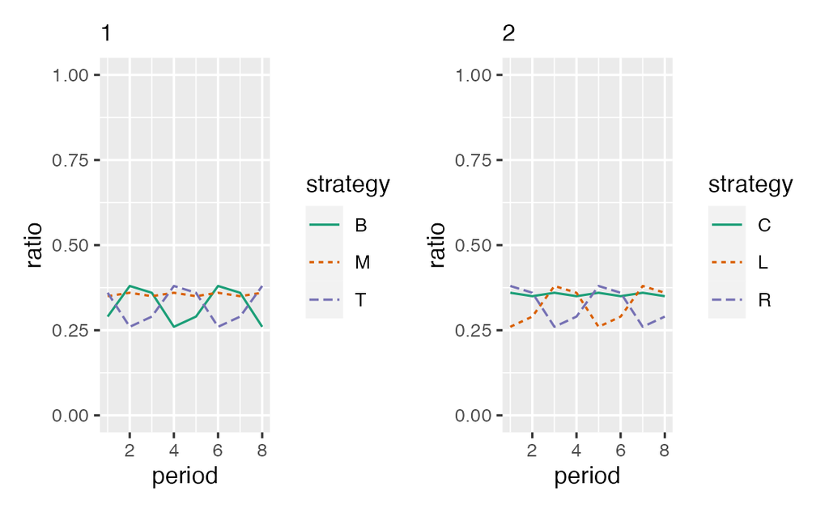

```r
g4_2x_sim$plot_mean
```

3. 先ほどと同様に、`game4_2` を関数、`sim_game()` でシミュレートし、ナッシュ均衡に到達するか確認。初期値 init1 = “M”, init2 = “C”

```r
g4_2x_sim <- sim_game(game4_2x,
                     n_samples = 100,
                     n_periods = 8,
                     init1 = "M",
                     init2 = "C")
```

|  | t | l | b | r |
| --- | --- | --- | --- | --- |
| 1: | 1 | 1 | 1 | 1 |
| 2: | 1 | 2 | 1 | 2 |

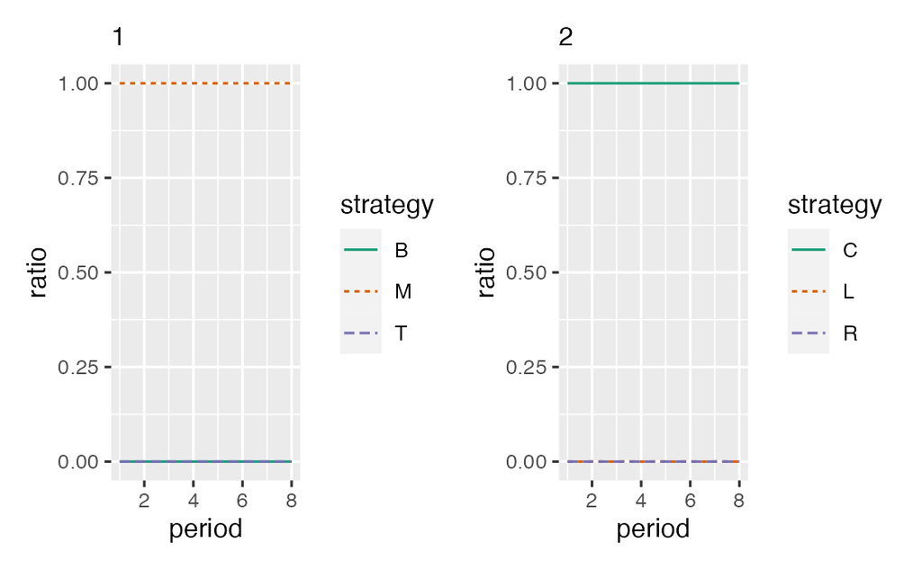

```r
g4_2x_sim$plot_mean
```

## 5.3 コラム

```r
p1 <- ggplot(myd) +
  geom_point(aes(x = var1, y = var2))
p2 <- p1 + labs(x = "変数1", y = "変数2")
plot(p2)
```

```r
p <- g1_sol2$br_plot
p + labs(x = "p1", y = "p2")
```

# 6 ナッシュ均衡の応用1：協力と調整

## 6.1 囚人のジレンマ

```r
game5_1 <- normal_form(
  players = c("1", "2"),
  s1 = c("C", "D"),
  s2 = c("C", "D"),
  payoffs1 = c(-2, -1, -10, -5) + 10,
  payoffs2 = c(-2, -10, -1, -5) + 10
)

g5_1_sol <- solve_nfg(game5_1)
```

```
Pure-strategy NE: [D, D]
```

|  | strategy | 2 C | 2 D |
| --- | --- | --- | --- |
| 1 | C | 8, 8 | 0, 9^ |
|  | D | 9^, 0 | 5^, 5^ |

## 6.2 共有地の悲劇

```r
game5_2 <- normal_form(
  players = c("1", "2"),
  s1 = c("20", "30"),
  s2 = c("20", "30"),
  payoffs1 = c(1000, 1200, 800, 900),
  payoffs2 = c(1000, 800, 1200, 900)
)

g5_2_sol <- solve_nfg(game5_2)
```

```
Pure-strategy NE: [30, 30]
```

|  | strategy | 2 20 | 2 30 |
| --- | --- | --- | --- |
| 1 | 20 | 1000, 1000 | 800, 1200^ |
|  | 30 | 1200^, 800 | 900^, 900^ |

### 6.2.1 ペナルティあり

共有地管理のペナルティ30

```r
game5_3 <- normal_form(
  players = c("1", "2"),
  s1 = c("20", "30"),
  s2 = c("20", "30"),
  payoffs1 = c(1000, 1200-400, 800, 900-400),
  payoffs2 = c(1000, 800, 1200-400, 900-400)
)

g5_3_sol <- solve_nfg(game5_3)
```

```
Pure-strategy NE: [20, 20]
```

|  | strategy | 2 20 | 2 30 |
| --- | --- | --- | --- |
| 1 | 20 | 1000^, 1000^ | 800^, 800 |
|  | 30 | 800, 800^ | 500, 500 |

## 6.3 調整ゲーム

```r
game5_4 <- normal_form(
  players = c("1", "2"),
  s1 = c("参加する", "参加しない"),
  s2 = c("参加する", "参加しない"),
  payoffs1 = c(950, 900, 900, 900),
  payoffs2 = c(950, 900, 900, 900)
)

g5_4_sol <- solve_nfg(game5_4)
```

```
Pure-strategy NE: [参加する, 参加する], [参加しない, 参加しない]
```

|  | strategy | 2 参加する | 2 参加しない |
| --- | --- | --- | --- |
| 1 | 参加する | 950^, 950^ | 900^, 900 |
|  | 参加しない | 900, 900^ | 900^, 900^ |

```r
g5_4_sim <- sim_game(game5_4,
                     n_samples = 100,
                     n_periods = 10)
```

|  | t | l | b | r |
| --- | --- | --- | --- | --- |
| 1: | 1 | 1 | 1 | 1 |
| 2: | 1 | 2 | 1 | 2 |

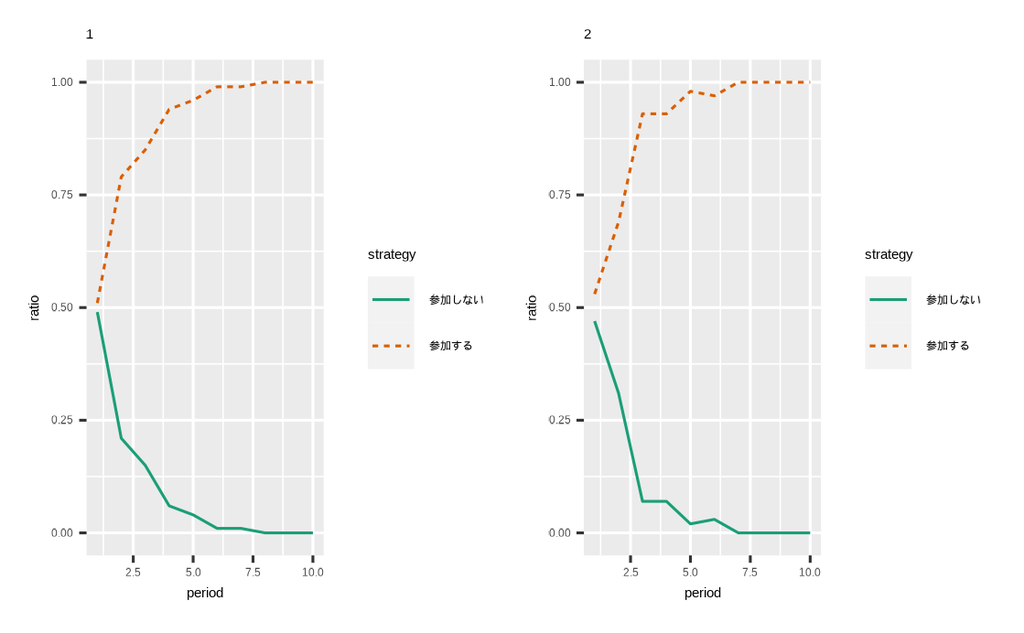

```r
g5_4_sim$plot_mean
```

```r
game5_5 <- normal_form(
  players = c("1", "2"),
  s1 = c("表", "裏"),
  s2 = c("表", "裏"),
  payoffs1 = c(2,0,0,1),
  payoffs2 = c(2,0,0,1)
)

g5_5_sol <- solve_nfg(game5_5)
```

```
Pure-strategy NE: [表, 表], [裏, 裏]
```

|  | strategy | 2 表 | 2 裏 |
| --- | --- | --- | --- |
| 1 | 表 | 2^, 2^ | 0, 0 |
|  | 裏 | 0, 0 | 1^, 1^ |

## 6.4 鹿狩りゲーム

```r
game5_6 <- normal_form(
  players = c("1", "2"),
  s1 = c("鹿", "兎"),
  s2 = c("鹿", "兎"),
  payoffs1 = c(3,2,0,2),
  payoffs2 = c(3,0,2,2)
)

g5_6_sol <- solve_nfg(game5_6)
```

```
Pure-strategy NE: [鹿, 鹿], [兎, 兎]
```

|  | strategy | 2 鹿 | 2 兎 |
| --- | --- | --- | --- |
| 1 | 鹿 | 3^, 3^ | 0, 2 |
|  | 兎 | 2, 0 | 2^, 2^ |

### 6.4.1 共有地の自主管理2

```r
game5_7 <- normal_form(
  players = c("1", "2"),
  s1 = c("参加する", "参加しない"),
  s2 = c("参加する", "参加しない"),
  payoffs1 = c(950, 900, 900-100, 900),
  payoffs2 = c(950, 900-100, 900, 900)
)

g5_7_sol <- solve_nfg(game5_7)
```

```
Pure-strategy NE: [参加する, 参加する], [参加しない, 参加しない]
```

|  | strategy | 2 参加する | 2 参加しない |
| --- | --- | --- | --- |
| 1 | 参加する | 950^, 950^ | 800, 900 |
|  | 参加しない | 900, 800 | 900^, 900^ |

## 6.5 練習問題

1. game5_1 では、両プレーヤーの利得に同じ値を足してもナッシュ均衡は、かわらなことを確認した。そでは、プレーヤー１の利得に、10 を、プレーヤー２の利得には、20を足すと、ナッシュ均衡は、変わるだろうか。

```r
game5_1x <- normal_form(
  players = c("1", "2"),
  s1 = c("C", "D"),
  s2 = c("C", "D"),
  payoffs1 = c(-2, -1, -10, -5) + 10,
  payoffs2 = c(-2, -10, -1, -5) + 20
)

g5_1_solx <- solve_nfg(game5_1x)
```

```
Pure-strategy NE: [D, D]
```

|  | strategy | 2 C | 2 D |
| --- | --- | --- | --- |
| 1 | C | 8, 18 | 0, 19^ |
|  | D | 9^, 10 | 5^, 15^ |

2. game5_3 のペナルティのある共有地の悲劇ゲームを思い出そう。ペナルティが弱く、ペナルティによる、利得の減少が 100 のとき、過剰放牧を抑制することは可能だろうか。また、ペナルティの値をいろいろと試してみることで、過剰放牧を抑制することができる。もっとも弱いペナルティの値は、いくつか考えてみよう。
3. game5_7 の共有地の自主管理2 のゲームにおける、プレーヤーの選択を関数、sim_game() でシミュレートしてみよう。

# 7 参考文献

- 私たちのR: https://www.jaysong.net/RBook/